# Autoencoder & GANs

Then we train the WGAN and visualize the training as before. The training of WGAN is unstable and when generated samples show some blurry digits may vary. Sometimes at epoch 60, there are still only grids in generated samples, and sometimes shape begins to appear around epoch 20.

```
Extracting MNIST-data/train-images-idx3-ubyte.gz
Extracting MNIST-data/train-labels-idx1-ubyte.gz
Extracting MNIST-data/t10k-images-idx3-ubyte.gz
Extracting MNIST-data/t10k-labels-idx1-ubyte.gz
```

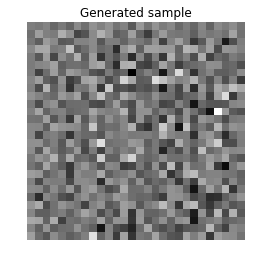

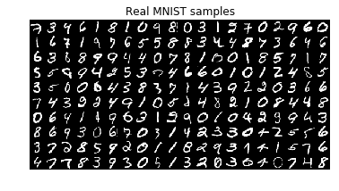

```
Epoch: [ 0] time: 8.59s, d_loss: -0.1605, g_loss: 0.4195
Epoch: [ 1] time: 16.72s, d_loss: 0.1630, g_loss: 0.3884
Epoch: [ 2] time: 24.95s, d_loss: 0.3762, g_loss: 0.2526
Epoch: [ 3] time: 33.16s, d_loss: 0.2218, g_loss: 0.3879
Epoch: [ 4] time: 41.30s, d_loss: 0.1162, g_loss: 0.5739
Epoch: [ 5] time: 49.52s, d_loss: 0.2054, g_loss: 0.5391
Epoch: [ 6] time: 57.71s, d_loss: -0.1629, g_loss: 0.7662
Epoch: [ 7] time: 65.98s, d_loss: 0.2055, g_loss: 0.5397
Epoch: [ 8] time: 74.12s, d_loss: 0.1775, g_loss: 0.5045
Epoch: [ 9] time: 82.38s, d_loss: -0.1650, g_loss: 0.9066
```

[figure not shown]

```
Epoch: [10] time: 91.80s, d_loss: -0.1420, g_loss: 0.8182
Epoch: [11] time: 100.05s, d_loss: 0.2241, g_loss: 0.5393
Epoch: [12] time: 108.21s, d_loss: -0.0222, g_loss: 0.6959
Epoch: [13] time: 116.36s, d_loss: 0.0003, g_loss: 0.7129
Epoch: [14] time: 124.61s, d_loss: 0.1559, g_loss: 0.4851
Epoch: [15] time: 132.79s, d_loss: 0.0181, g_loss: 0.7331
Epoch: [16] time: 140.93s, d_loss: -0.0020, g_loss: 0.7672
Epoch: [17] time: 149.11s, d_loss: 0.0626, g_loss: 0.5725
Epoch: [18] time: 157.19s, d_loss: -0.0546, g_loss: 0.7027
Epoch: [19] time: 165.39s, d_loss: 0.2446, g_loss: 0.4808
```

[figure not shown]

```
Epoch: [20] time: 175.13s, d_loss: 0.5146, g_loss: 0.2212
Epoch: [21] time: 183.27s, d_loss: 0.2935, g_loss: 0.4970
Epoch: [22] time: 191.41s, d_loss: 0.2706, g_loss: 0.5016
Epoch: [23] time: 199.61s, d_loss: 0.2475, g_loss: 0.3866
Epoch: [24] time: 207.77s, d_loss: 0.0857, g_loss: 0.5888
Epoch: [25] time: 215.97s, d_loss: 0.1665, g_loss: 0.5473
Epoch: [26] time: 224.20s, d_loss: 0.3806, g_loss: 0.3764
Epoch: [27] time: 232.40s, d_loss: 0.1685, g_loss: 0.5511
Epoch: [28] time: 240.56s, d_loss: 0.1763, g_loss: 0.4750
Epoch: [29] time: 248.73s, d_loss: 0.1586, g_loss: 0.3638
```

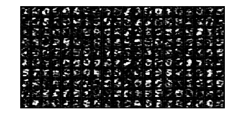

```
Epoch: [30] time: 258.13s, d_loss: 0.2048, g_loss: 0.5181
Epoch: [31] time: 266.25s, d_loss: 0.1976, g_loss: 0.5132
Epoch: [32] time: 274.33s, d_loss: 0.2678, g_loss: 0.2784
Epoch: [33] time: 282.52s, d_loss: 0.0961, g_loss: 0.4808
Epoch: [34] time: 290.68s, d_loss: 0.2502, g_loss: 0.4601
Epoch: [35] time: 298.89s, d_loss: 0.2400, g_loss: 0.2574
Epoch: [36] time: 307.05s, d_loss: -0.0422, g_loss: 0.5078
Epoch: [37] time: 315.22s, d_loss: 0.0659, g_loss: 0.4704
Epoch: [38] time: 323.48s, d_loss: 0.1326, g_loss: 0.3251
Epoch: [39] time: 331.68s, d_loss: -0.0217, g_loss: 0.5367
```

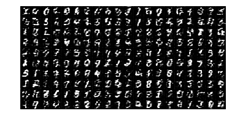

```
Epoch: [40] time: 341.16s, d_loss: 0.1375, g_loss: 0.5137
Epoch: [41] time: 349.30s, d_loss: 0.1792, g_loss: 0.2806
Epoch: [42] time: 357.38s, d_loss: -0.0377, g_loss: 0.5232
Epoch: [43] time: 365.58s, d_loss: -0.0855, g_loss: 0.5706
Epoch: [44] time: 373.74s, d_loss: 0.0328, g_loss: 0.3058
Epoch: [45] time: 381.93s, d_loss: -0.0305, g_loss: 0.4933
Epoch: [46] time: 390.12s, d_loss: -0.1100, g_loss: 0.4977
Epoch: [47] time: 394.19s, d_loss: 0.0499, g_loss: 0.3242
Epoch: [48] time: 397.75s, d_loss: -0.0670, g_loss: 0.4966
Epoch: [49] time: 401.30s, d_loss: -0.0891, g_loss: 0.5168
```

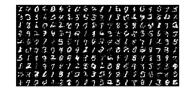

```
Epoch: [50] time: 407.93s, d_loss: 0.0241, g_loss: 0.2714
Epoch: [51] time: 416.03s, d_loss: -0.2074, g_loss: 0.5418
Epoch: [52] time: 424.23s, d_loss: -0.0648, g_loss: 0.4912
Epoch: [53] time: 432.57s, d_loss: 0.0426, g_loss: 0.2445
Epoch: [54] time: 440.76s, d_loss: -0.2611, g_loss: 0.5889
Epoch: [55] time: 448.89s, d_loss: -0.1756, g_loss: 0.5217
Epoch: [56] time: 457.01s, d_loss: -0.0422, g_loss: 0.2831
Epoch: [57] time: 465.17s, d_loss: -0.2666, g_loss: 0.5362
Epoch: [58] time: 473.34s, d_loss: -0.0076, g_loss: 0.4518
Epoch: [59] time: 481.51s, d_loss: -0.1064, g_loss: 0.2717
```

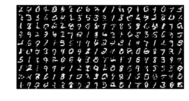

```
Epoch: [60] time: 490.92s, d_loss: -0.1700, g_loss: 0.4900
Epoch: [61] time: 499.11s, d_loss: -0.0847, g_loss: 0.4223
Epoch: [62] time: 507.22s, d_loss: -0.1674, g_loss: 0.2894
Epoch: [63] time: 515.34s, d_loss: -0.2194, g_loss: 0.5255
Epoch: [64] time: 523.55s, d_loss: -0.2004, g_loss: 0.5104
Epoch: [65] time: 531.75s, d_loss: -0.1026, g_loss: 0.2256
Epoch: [66] time: 539.94s, d_loss: -0.1466, g_loss: 0.4750
Epoch: [67] time: 548.13s, d_loss: -0.3172, g_loss: 0.5298
Epoch: [68] time: 556.26s, d_loss: 0.0058, g_loss: 0.1917
Epoch: [69] time: 564.48s, d_loss: -0.1316, g_loss: 0.4460
```

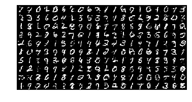

```
Epoch: [70] time: 574.13s, d_loss: -0.1745, g_loss: 0.4858
Epoch: [71] time: 582.28s, d_loss: -0.0660, g_loss: 0.1949
Epoch: [72] time: 590.52s, d_loss: -0.1647, g_loss: 0.4336
Epoch: [73] time: 598.69s, d_loss: -0.2057, g_loss: 0.4696
Epoch: [74] time: 606.83s, d_loss: -0.1593, g_loss: 0.2692
Epoch: [75] time: 614.99s, d_loss: -0.1441, g_loss: 0.4444
Epoch: [76] time: 623.15s, d_loss: -0.1343, g_loss: 0.4530
Epoch: [77] time: 631.33s, d_loss: -0.0608, g_loss: 0.2048
Epoch: [78] time: 639.57s, d_loss: -0.2662, g_loss: 0.4595
Epoch: [79] time: 647.77s, d_loss: -0.2955, g_loss: 0.4732
```

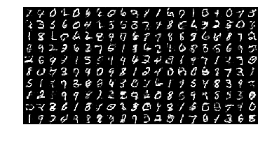

```
Epoch: [80] time: 657.22s, d_loss: -0.1225, g_loss: 0.2096
Epoch: [81] time: 665.30s, d_loss: -0.2002, g_loss: 0.4722
Epoch: [82] time: 673.45s, d_loss: -0.1655, g_loss: 0.4110
Epoch: [83] time: 681.64s, d_loss: -0.1607, g_loss: 0.2565
Epoch: [84] time: 689.86s, d_loss: -0.0756, g_loss: 0.3887
Epoch: [85] time: 698.07s, d_loss: -0.1169, g_loss: 0.3841
Epoch: [86] time: 706.18s, d_loss: -0.1712, g_loss: 0.2341
Epoch: [87] time: 714.40s, d_loss: -0.2321, g_loss: 0.4151
Epoch: [88] time: 722.58s, d_loss: -0.1339, g_loss: 0.3788
Epoch: [89] time: 730.75s, d_loss: -0.1013, g_loss: 0.1749
```

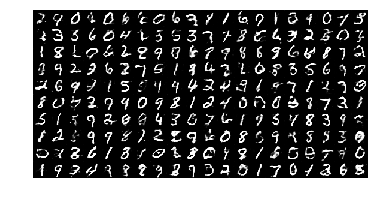

```
Epoch: [90] time: 740.44s, d_loss: -0.2137, g_loss: 0.4119
Epoch: [91] time: 748.67s, d_loss: -0.1886, g_loss: 0.3836
Epoch: [92] time: 756.86s, d_loss: -0.0811, g_loss: 0.2023
Epoch: [93] time: 765.04s, d_loss: -0.1949, g_loss: 0.4098
Epoch: [94] time: 773.14s, d_loss: -0.2442, g_loss: 0.3997
Epoch: [95] time: 781.24s, d_loss: -0.1943, g_loss: 0.2524
Epoch: [96] time: 789.40s, d_loss: -0.2391, g_loss: 0.4112
Epoch: [97] time: 797.53s, d_loss: -0.2901, g_loss: 0.4277
Epoch: [98] time: 805.66s, d_loss: -0.1101, g_loss: 0.1715
Epoch: [99] time: 813.89s, d_loss: -0.1760, g_loss: 0.3925
```

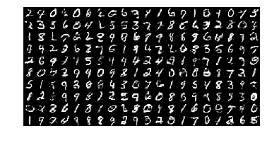

```python
# Specifiy model checkpoint directory & samples directory
checkpoint_dir = 'checkpoint'
samples_dir = 'samples'

sess = tf.Session()
model = WGAN(
    sess,
    input_width=28,
    input_height=28,
    output_width=28,
    output_height=28,
    batch_size=128,
    input_fname_pattern='*.jpg',
    checkpoint_dir=checkpoint_dir,
    samples_dir=samples_dir,
    show_samples=True,
    epoch=100)

# show_all_variables()
init = tf.global_variables_initializer()
sess.run(init)
sample_z = np.random.uniform(-1, 1, size=(200, 100))
samples = model.G.eval(session=model.sess, feed_dict={model.z: sample_z})
plt.imshow(samples[0].reshape(28, 28), cmap='gray')
plt.axis('off')
plt.title('Generated sample')
plt.show()

samples = model.trX[:200]
img = grayscale_grid_vis(samples, nhw=(10, 20))
plt.imshow(img, cmap='gray')
plt.axis('off')
plt.title('Real MNIST samples')
plt.show()

model.train()
```

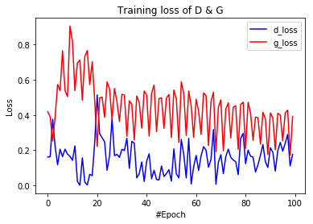

```python
d_loss = model.log['d_loss']
g_loss = model.log['g_loss']
plt.plot(range(len(d_loss)), d_loss, color='blue', label='d_loss')
plt.plot(range(len(g_loss)), g_loss, color='red', label='g_loss')
plt.legend(loc="upper right")
plt.xlabel('#Epoch')
plt.ylabel('Loss')
plt.title('Training loss of D & G')
plt.show()
```

```python
imgs = np.array(model.log['gen_samples'])
make_gif(imgs * 255., 'GAN/wgan.gif', true_image=True, duration=2)

from IPython.display import Image
Image(url='GAN/wgan.gif')
```

[figure not shown]

```python
tf.reset_default_graph()
sess.close()
```

# Improved WGAN

Although Wasserstein GAN (WGAN) made progress toward stable training of GANs, still fail to converge in some settings. In this lab, you are required to implement [Improved Wasserstein GANs](https://arxiv.org/pdf/1704.00028.pdf), which is a milestone for GANs research.

We will show the training result of Improved WGAN below, which indicates that, compared to WGAN, Improved WGAN has a much better performance. It generates recognizable digits much faster during the training process.

Details of the algorithm are shown below.

[figure not shown]

```python
from IPython.display import Image
Image(url='GAN/iwgan.gif')
```

[figure not shown]

# Assignment

There are two exercises in this lab.

## Exercise 1

Train an autoencoder model on [Horse Images (gray scale)](http://www.msri.org/people/members/eranb/). Then pick one horse image and plot its manifold just like the demo in this lab.

## Exercise 2

Implement the [Improved WGAN](https://arxiv.org/pdf/1704.00028.pdf) and train it on the MNIST dataset. Then draw a gif of generated samples (10 x 20) to demonstrate the training process and show the best-generated samples you get.

Hint: You are encouraged to modify the codes based on the DCGAN.

## Notification

- Submit the notebook file to demonstrate your codes and experiment result on iLMS.
- Give a brief report to on what you have done.
- The deadline will be 2017/12/29 23:59